# Bayesian Logistic Regression for Predicting Diabetes Risk Using NHANES 2013–2014 Data

# Visualizations

## 1. Data Quality & Missingness

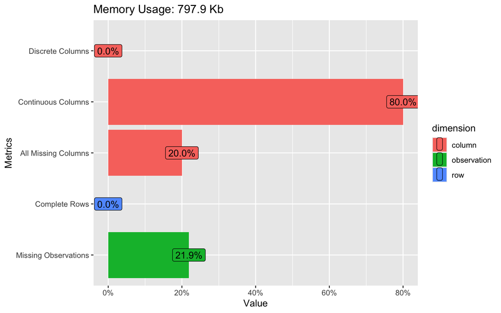

Figure 5: Variable overview and missing-data patterns (NHANES 2013–2014).

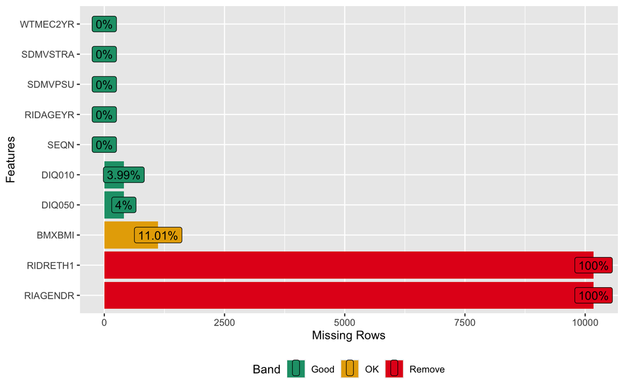

Figure 6: Variable overview and missing-data patterns (NHANES 2013–2014).

```r
plot_intro(merged_data)
plot_missing(merged_data)
```

## 2. Exploratory Distributions

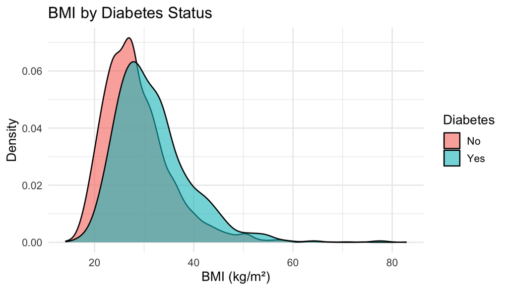

Figure 7: BMI distribution by diabetes status (adult cohort, ≥20y).

```r
adult %>%
filter(!is.na(diabetes_dx), !is.na(bmi)) %>%
mutate(diabetes_f = factor(diabetes_dx, levels = c(0,1), labels = c("No","Yes"))) %>%
ggplot(aes(x = bmi, fill = diabetes_f)) +
geom_density(alpha = 0.6) +
labs(x = "BMI (kg/m²)", y = "Density", fill = "Diabetes", title = "BMI by Diabetes Status")
```

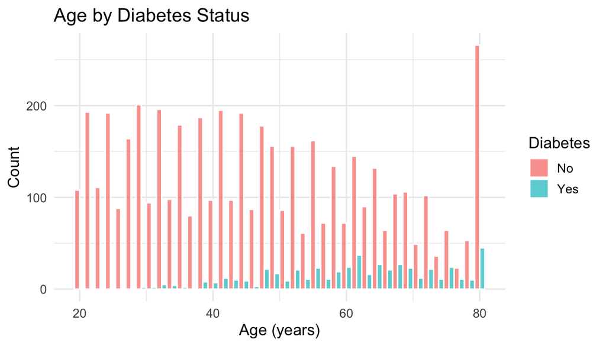

Figure 8: Age distribution by diabetes status (adult cohort, ≥20y).

```r
adult %>%
filter(!is.na(diabetes_dx), !is.na(age)) %>%
mutate(diabetes_f = factor(diabetes_dx, levels = c(0,1), labels = c("No","Yes"))) %>%
ggplot(aes(x = age, fill = diabetes_f)) +
geom_histogram(position = "dodge", alpha = 0.7, bins = 40, color = "white") +
labs(x = "Age (years)", y = "Count", fill = "Diabetes", title = "Age by Diabetes Status")
```

## 3. Posterior Mean Probability vs BMI (Bayesian)

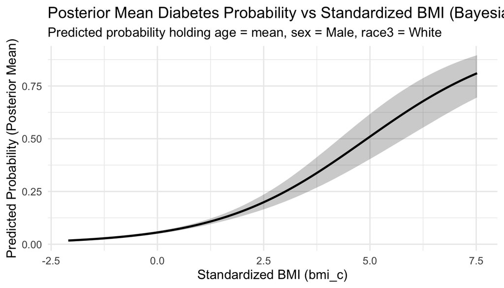

Figure 9: Posterior mean predicted probability of diabetes vs standardized BMI (bmi_c), holding other covariates at reference/mean.

```r
pp_df <- tibble(
  bmi_c = seq(min(adult$bmi_c, na.rm = TRUE), max(adult$bmi_c, na.rm = TRUE), length.out = 120),
  age_c = mean(adult$age_c, na.rm = TRUE),
  sex   = factor("Male",  levels = levels(adult$sex)),
  race3 = factor("White", levels = levels(adult$race3))
)
pp_pred <- posterior_epred(bayes_fit, newdata = pp_df)  # draws x N
pp_df <- pp_df %>%
mutate(
pred  = colMeans(pp_pred),
lower = apply(pp_pred, 2, quantile, 0.025),
upper = apply(pp_pred, 2, quantile, 0.975)
)
ggplot(pp_df, aes(x = bmi_c, y = pred)) +
geom_ribbon(aes(ymin = lower, ymax = upper), alpha = 0.25) +
geom_line(linewidth = 1) +
labs(
  title = "Posterior Mean Diabetes Probability vs Standardized BMI (Bayesian Model)",
  subtitle = "Predicted probability holding age = mean, sex = Male, race3 = White",
  x = "Standardized BMI (bmi_c)",
  y = "Predicted Probability (Posterior Mean)"
)
```

## 4. Priors vs Posteriors (Key Coefficients)

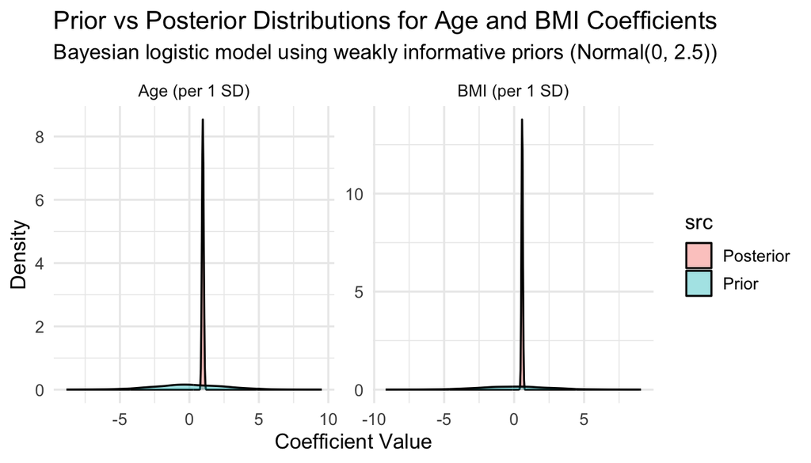

Figure 10: Illustrative prior (Normal(0,2.5)) vs posterior for age and BMI coefficients.

```r
set.seed(1)
prior_draws <- tibble(
term  = rep(c("Age (per 1 SD)", "BMI (per 1 SD)"), each = 4000),
value = c(rnorm(4000, 0, 2.5), rnorm(4000, 0, 2.5)),
src   = "Prior"
)
post_draws <- posterior::as_draws_df(bayes_fit) %>%
select(b_age_c, b_bmi_c) %>%
pivot_longer(everything(), names_to = "raw", values_to = "value") %>%
mutate(term = recode(raw, b_age_c = "Age (per 1 SD)", b_bmi_c = "BMI (per 1 SD)"),
src = "Posterior") %>%
select(term, value, src)
bind_rows(prior_draws, post_draws) %>%
ggplot(aes(x = value, fill = src)) +
geom_density(alpha = 0.4) +
facet_wrap(~ term, scales = "free") +
labs(
  title = "Prior vs Posterior Distributions for Age and BMI Coefficients",
  subtitle = "Bayesian logistic model using weakly informative priors (Normal(0, 2.5))",
  x = "Coefficient Value",
  y = "Density"
)
```

## 5. Posterior Predictive Checks

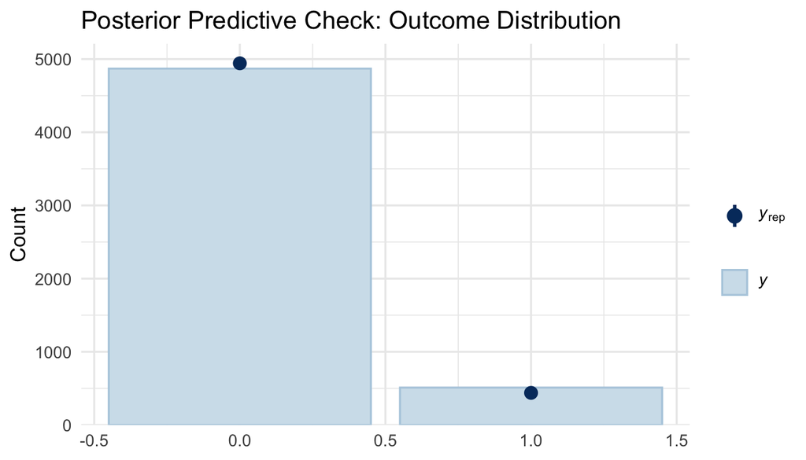

Figure 11: Posterior predictive checks for outcome distribution and mean.

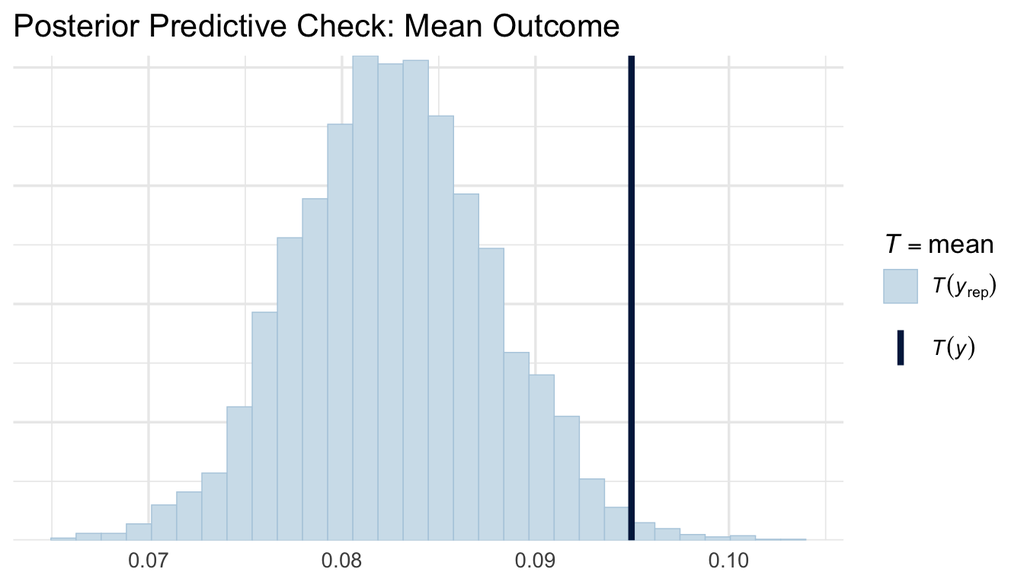

Figure 12: Posterior predictive checks for outcome distribution and mean.

```r
pp_check(bayes_fit, type = "bars") + ggtitle("Posterior Predictive Check: Outcome Distribution")
pp_check(bayes_fit, type = "stat", stat = "mean") + ggtitle("Posterior Predictive Check: Mean Outcome")
```

## 6. Observed vs Predicted (Calibration-style)

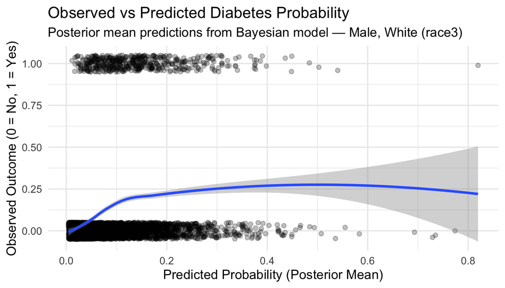

Figure 13: Observed outcome vs posterior mean predicted probability (calibration-style view).

```r
bayes_pred <- posterior_epred(bayes_fit, newdata = adult)  # draws x N
pred_prob  <- colMeans(bayes_pred)
adult_plot <- adult %>% mutate(pred_prob = pred_prob)
ggplot(adult_plot, aes(x = pred_prob, y = as.numeric(diabetes_dx))) +
geom_jitter(height = 0.05, alpha = 0.25) +
geom_smooth(method = "loess", se = TRUE) +
labs(
  title = "Observed vs Predicted Diabetes Probability",
  subtitle = "Posterior mean predictions from Bayesian model — Male, White (race3)",
  x = "Predicted Probability (Posterior Mean)",
  y = "Observed Outcome (0 = No, 1 = Yes)"
)
```

## 7. Posterior vs Survey-Weighted Prevalence

[figure not shown]

```r
pop_prev  <- as.numeric(svymean(~diabetes_dx, nhanes_design_adult, na.rm = TRUE))
post_prev <- mean(colMeans(bayes_pred))
bar_df <- tibble(
Source     = c("Survey-weighted (Population)", "Bayesian Posterior"),
Prevalence = c(pop_prev, post_prev)
)
ggplot(bar_df, aes(x = Source, y = Prevalence, fill = Source)) +
geom_col(alpha = 0.85) +
guides(fill = "none") +
labs(
  title = "Population vs Posterior Diabetes Prevalence",
  subtitle = "Survey-weighted estimate (design-based) vs Bayesian (model-based)",
  y = "Prevalence (Proportion with Diabetes)",
  x = NULL
)
```

# Reproducibility Notes

All code was executed in R 4.3+ using RStudio. Key packages include: `nhanesA`, `tidyverse`, `survey`, `mice`, `brms`, `bayesplot`, and `knitr`. Data preparation and modeling scripts are contained in the project’s repository and are rendered via Quarto in this document. For imputation and prior choices, see (Buuren 2012; Vande Schoot et al. 2021). For survey design and weighting details, see (National Center for Health Statistics (NCHS) 2014).

## References

Abdullah, H., R. Hassan, and B. Mustafa. 2022. “A Review on Bayesian Deep Learning in Healthcare: Applications and Challenges.” *Artificial Intelligence in Medicine* 128: 102312. https://doi.org/10.1016/j.artmed.2022.102312.

Austin, P. C., I. R. White, D. S. Lee, and S. van Buuren. 2021. “Missing Data in Clinical Research: A Tutorial on Multiple Imputation.” *Canadian Journal of Cardiology* 37 (9): 1322–31. https://doi.org/10.1016/j.cjca.2020.11.010.

Baldwin, S. A., and M. J. Larson. 2017. “An Introduction to Using Bayesian Linear Regression with Clinical Data.” *Behaviour Research and Therapy* 98: 58–75. https://doi.org/10.1016/j.brat.2017.05.014.

Buuren, S. van. 2012. *Flexible Imputation of Missing Data*. Boca Raton, FL: Chapman; Hall/CRC. https://doi.org/10.1201/b11826.

Chatzimichail, T., and A. T. Hatjimihail. 2023. “A Bayesian Inference-Based Computational Tool for Parametric and Nonparametric Medical Diagnosis.” *Diagnostics* 13 (19): 3135. https://doi.org/10.3390/diagnostics13193135.

Gelman, A., A. Jakulin, M. G. Pittau, and Y. S. Su. 2008. “A Weakly Informative Default Prior Distribution for Logistic and Other Regression Models.” *Annals of Applied Statistics* 2 (4): 1360–83. https://doi.org/10.1214/08-AOAS191.

Hoeting, J. A., D. Madigan, A. E. Raftery, and C. T. Volinsky. 1999. “Bayesian Model Averaging: A Tutorial.” *Statistical Science* 14 (4): 382–417. https://doi.org/10.1214/ss/1009212519.

Klauenberg, K., G. Wübbeler, B. Mickan, P. Harris, and C. Elster. 2015. “A Tutorial on Bayesian Normal Linear Regression.” *Metrologia* 52 (6): 878–92. https://doi.org/10.1088/0026-1394/52/6/878.

Kruschke, J. K., and T. M. Liddell. 2017. “Bayesian Data Analysis for Newcomers.” *Psychonomic Bulletin & Review* 25 (1): 155–77. https://doi.org/10.3758/s13423-017-1272-1.

Liu, Y. M., S. L. S. Chen, A. M. F. Yen, and H. H. Chen. 2013. “Individual Risk Prediction Model for Incident Cardiovascular Disease: A Bayesian Clinical Reasoning Approach.” *International Journal of Cardiology* 167 (5): 2008–12. https://doi.org/10.1016/j.ijcard.2012.05.016.

Luo, C., X. Sun, Y. Zhao, and H. Guo. 2024. “Variable Selection and Model Averaging in Bayesian Additive Regression Trees: A Comparative Study.” *Journal of Computational and Graphical Statistics*. https://doi.org/10.1080/10618600.2024.2401234.

Momeni, F., F. Momeni, A. Moradi, M. Shabani, and B. Amani. 2021. “Bayesian State-Space Modeling of Dynamic COVID-19 Risk Prediction Using Time-Varying Biomarkers.” *Scientific Reports* 11 (1): 20387. https://doi.org/10.1038/s41598-021-99711-7.

National Center for Health Statistics (NCHS). 2014. “National Health and Nutrition Examination Survey (NHANES) 2013–2014 Data Documentation, Codebook, and Frequencies.” U.S. Department of Health; Human Services, Centers for Disease Control; Prevention. https://wwwn.cdc.gov/nchs/nhanes/continuousnhanes/overview.aspx?BeginYear=2013.

Richardson, Robert, and Brian Hartman. 2018. “Bayesian Nonparametric Regression Models for Modeling and Predicting Healthcare Claims.” *Insurance: Mathematics and Economics* 83: 1–8. https://doi.org/10.1016/j.insmatheco.2018.06.002.

Vande Schoot, R., S. Depaoli, R. King, B. Kramer, K. Märtens, M. G. Tadesse, M. Vannucci, et al. 2021. “Bayesian Statistics and Modelling.” *Nature Reviews Methods Primers* 1: 1–26. https://doi.org/10.1038/s43586-020-00001-2.

Zeger, S. L., Z. Wu, Y. Coley, A. T. Fojo, B. Carter, K. O’Brien, P. Zandi, et al. 2020. “Using a Bayesian Approach to Predict Patients’ Health and Response to Treatment.” 272. Johns Hopkins Biostatistics Working Paper Series. https://biostats.bepress.com/jhubiostat/paper272.